# TimeSeries

Zhejia Dong

2023-04-15

# MA(2) - second order moving average process

$$Y_t = e_t + \theta_1 e_{t-1} + \theta_2 e_{t-2}$$
where $e_{i}$ is white noise from $N(0, \sigma_e^2)$. Then we can get the variance and covariance as follows:

$$\begin{align*}
\gamma_0 & = Var(\gamma_t) = Var(e_t + \theta_1 e_{t-1} + \theta_2
e_{t-2}) = (1+\theta^2_1 + \theta^2_2) \sigma^2_e\\
\gamma_1 & = Cov(Y_t, Y_{t-1}) \\
& = Cov(e_t + \theta_1 e_{t-1} + \theta_2 e_{t-2}, e_{t-1} +
\theta_1 e_{t-2} + \theta_2 e_{t-3} )\\
& = (\theta_1 + \theta_1\theta_2)\sigma^2_e\\
\gamma_2& = Cov(Y_t, Y_{t-2})\\
& =Cov(e_t + \theta_1 e_{t-1} + \theta_2 e_{t-2}, e_{t-2} + \theta_1
e_{t-3} + \theta_2 e_{t-4} )\\
& = \theta_2\sigma^2_e
\end{align*}$$

For a MA(2) time series {$Y_t$},$t = 1,2,\cdots, n$, the variance matrix should be

$$\begin{bmatrix}
1 + \theta_1^2 + \theta_2^2 & \theta_1 + \theta_1\theta_2
& \theta_2 & 0 & \cdots & 0 \\
\theta_1 + \theta_1\theta_2 & 1 + \theta_1^2 + \theta_2^2
& \theta_1 + \theta_1\theta_2 & \theta_2 & \cdots & 0
\\
\theta_2 & \theta_1 + \theta_1\theta_2 & 1 + \theta_1^2 +
\theta_2^2 & \theta_1 + \theta_1\theta_2 & \cdots & 0 \\
0 & \theta_2 & \theta_1 + \theta_1\theta_2 & 1 +
\theta_1^2 + \theta_2^2 & \cdots & 0 \\
\vdots & \vdots & \vdots & \vdots & \ddots &
\vdots \\
0 & 0 & 0 & 0 & \cdots & 1 + \theta_1^2 +
\theta_2^2
\end{bmatrix} \sigma^2_e$$

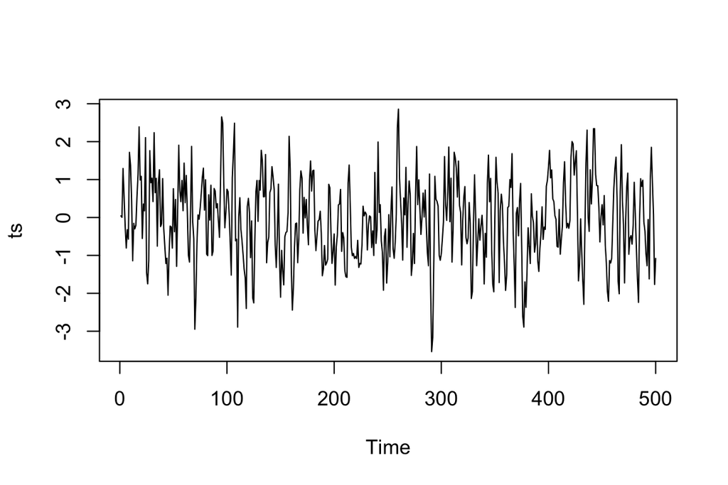

## First simulation MA(2) (0.7,0.3)

- cross correlation function plot

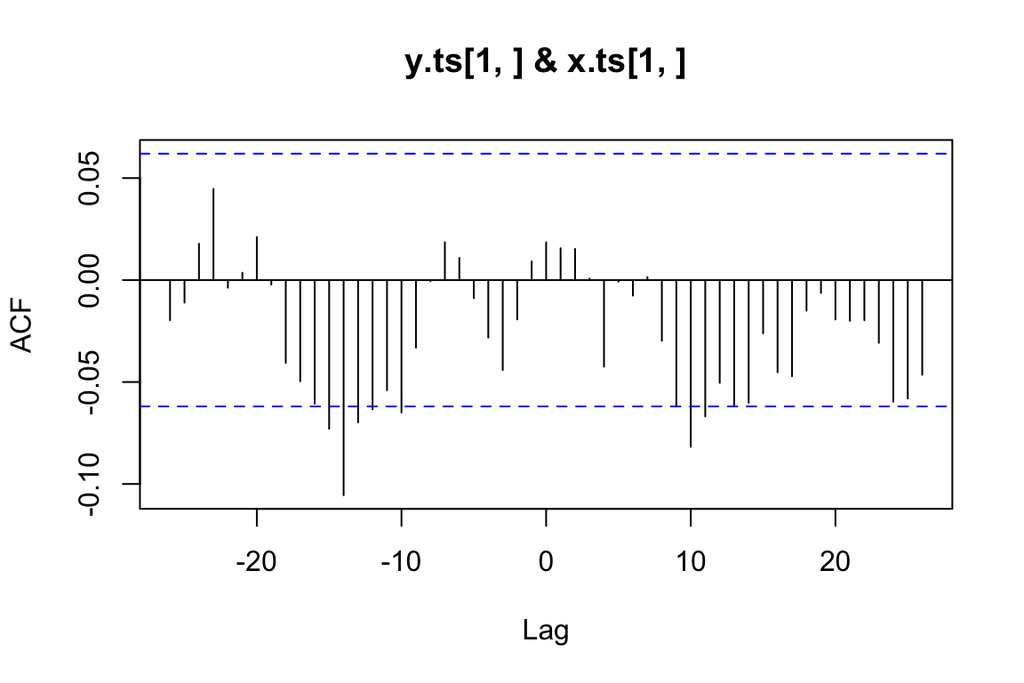

- Correlation coefficients (ccf at lag 0)
- Distance correlation
- Standard beta correlation
- Rejection rates of linear and distance correlation test

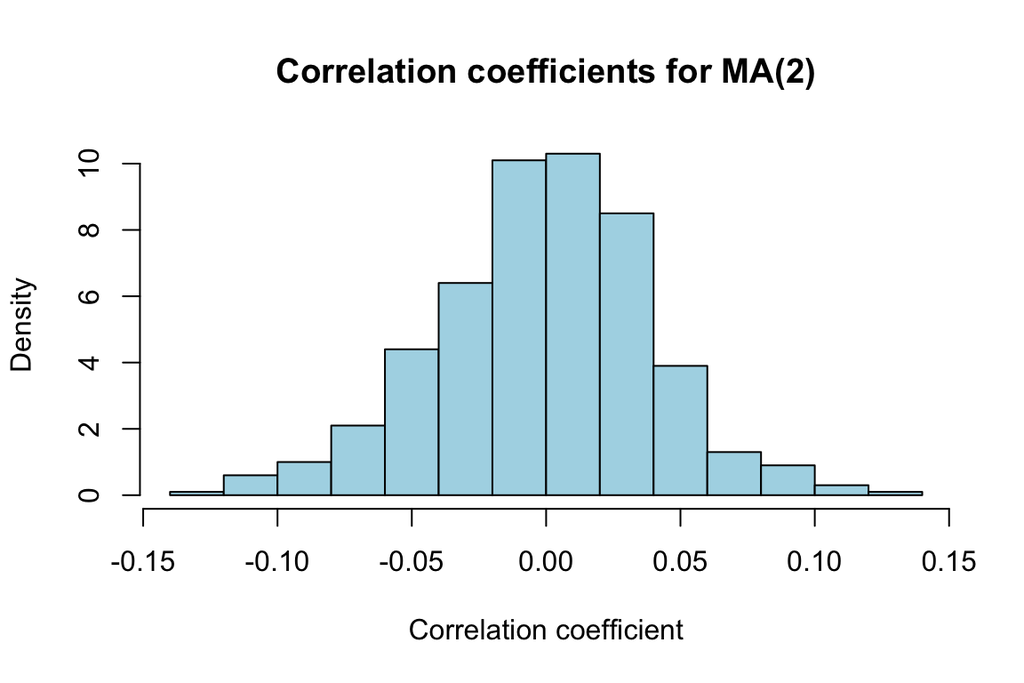

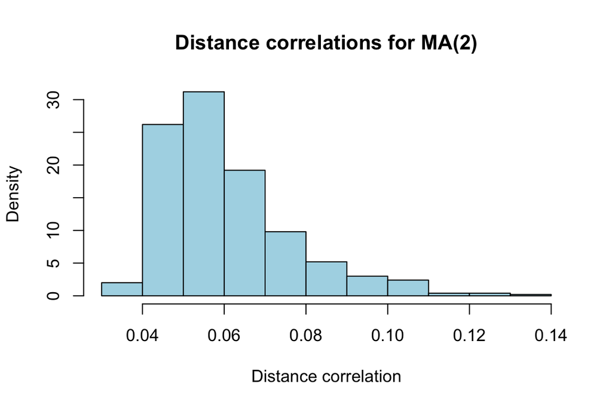

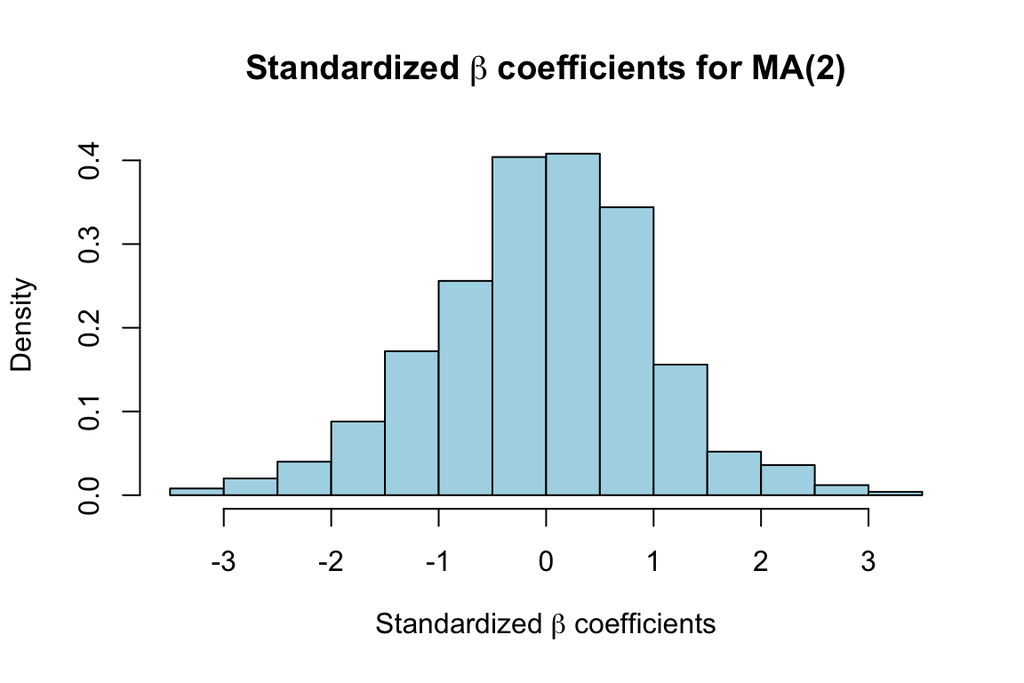

Rejection rates for linear and distance correlation test

| linear.test | dis.test |
| --- | --- |
| 0.118 | 0.152 |

## Second simulation MA(2) (0.9,0.9) highly correlated

- cross correlation function plot

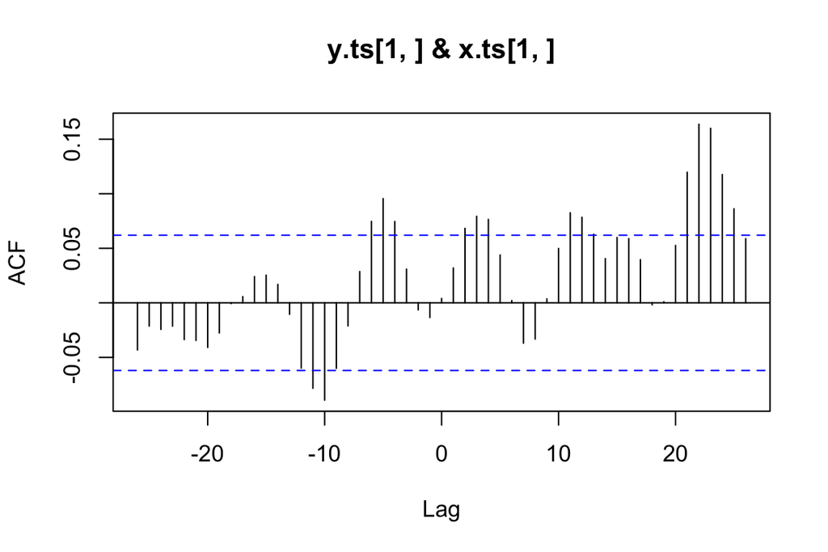

- Correlation coefficients (ccf at lag 0)
- Distance correlation
- Standard beta correlation
- Rejection rates of linear and distance correlation test

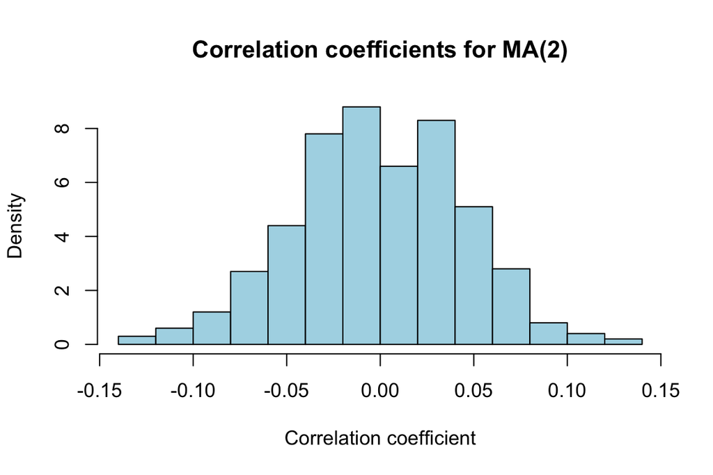

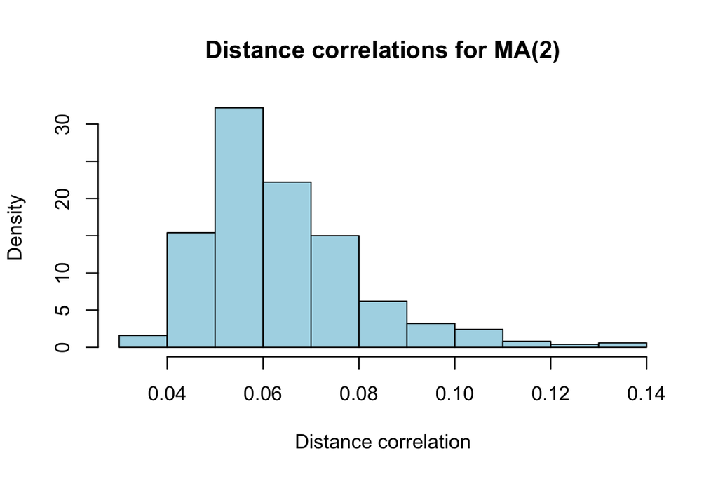

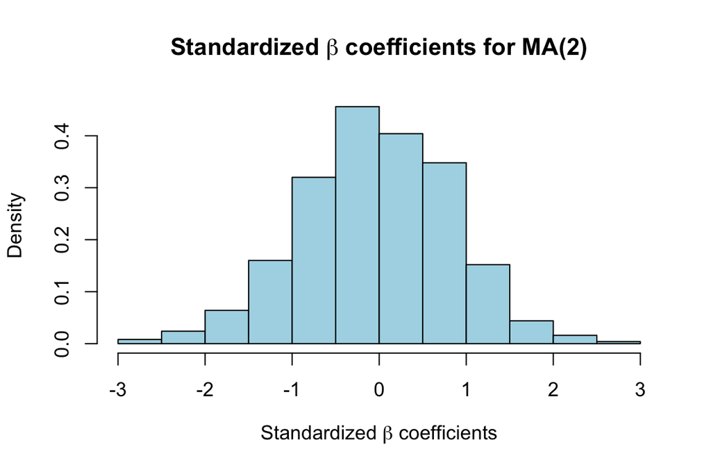

Rejection rates for linear and distance correlation test

| linear.test | dis.test |
| --- | --- |
| 0.16 | 0.224 |

## AR(2)

Then we consider auto regressive process.

$$Y_t = \phi_1 Y_{t-1} + \phi_2 Y_{t-2} +
e_t$$
AR characteristic polynomial $\phi(x) = 1 -\phi_1x -\phi_2 x^2$

A simple sample：

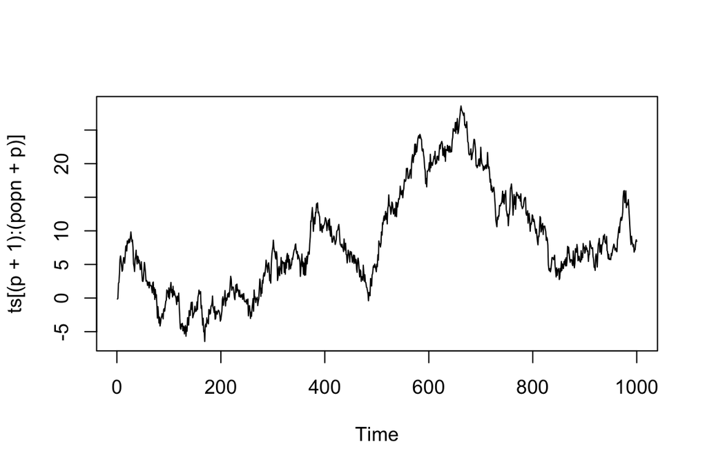

## AR(2) (0.7,0.3)

- cross correlation function plot

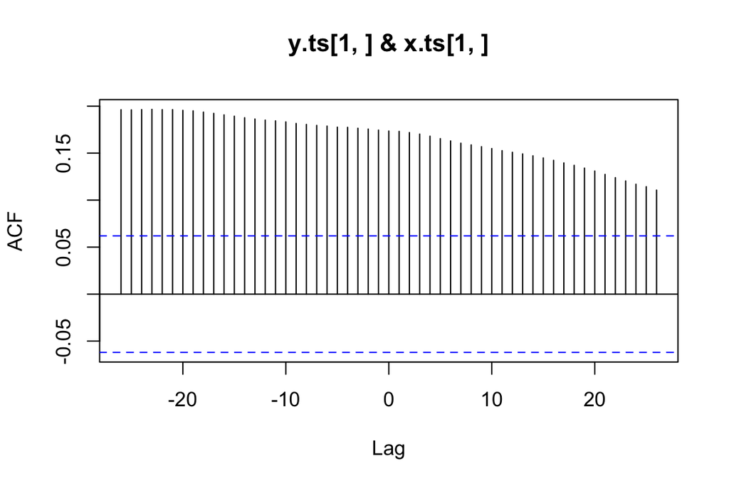

- Correlation coefficients (ccf at lag 0)
- Distance correlation
- Standard beta correlation
- Rejection rates of linear and distance correlation test

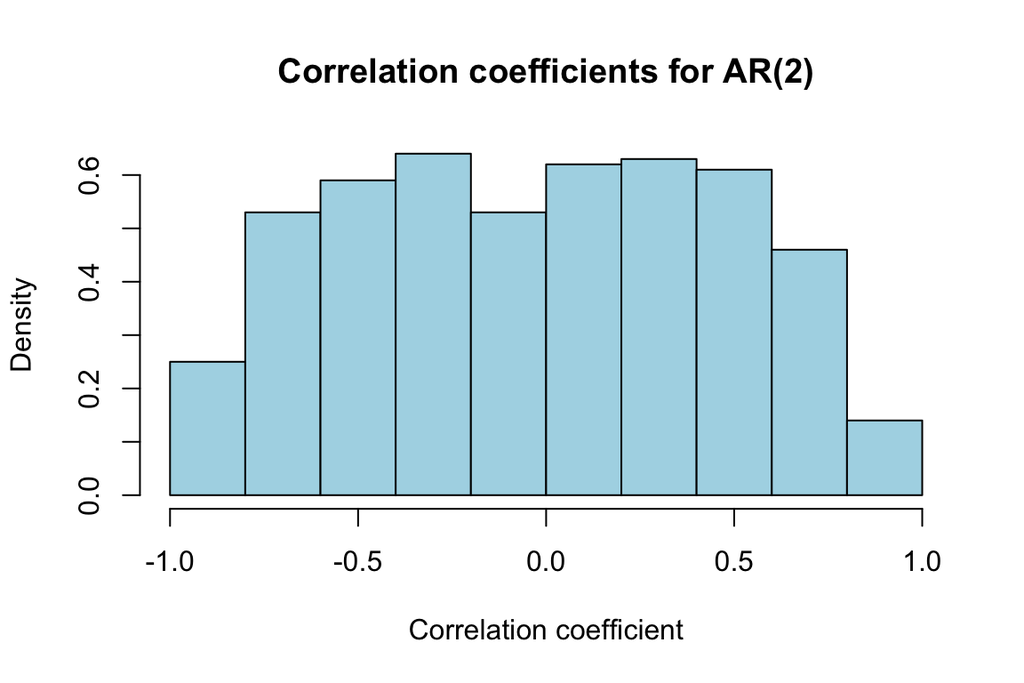

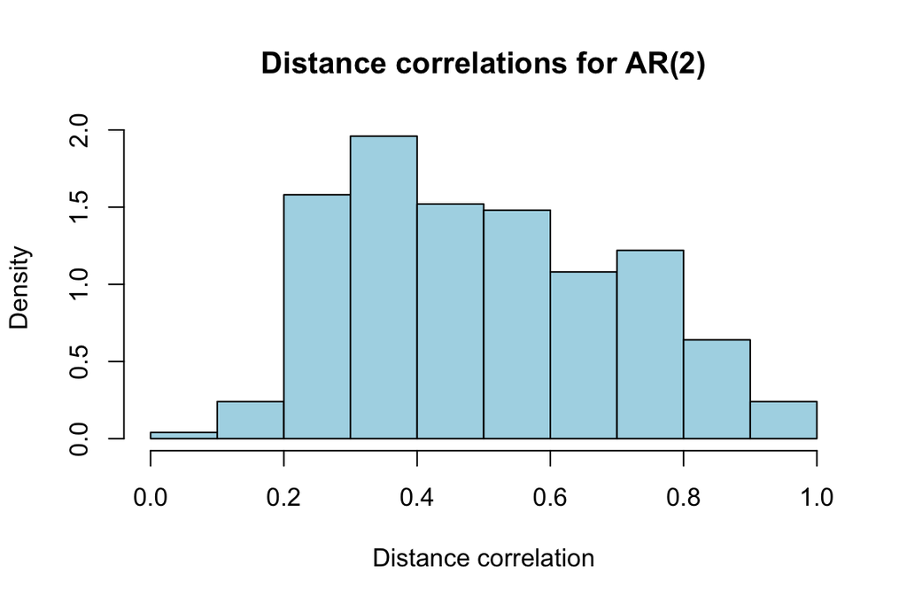

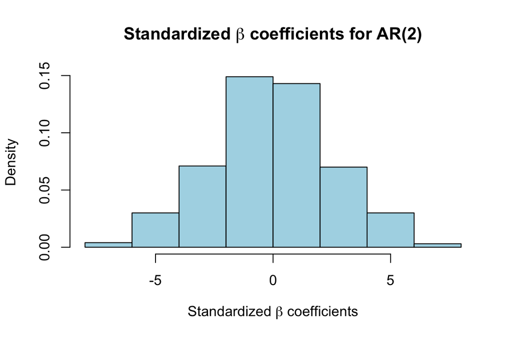

Rejection rates for linear and distance correlation test

| linear.test | dis.test |
| --- | --- |
| 0.906 | 1 |

## AR(2) (0.6, 0.4)

- cross correlation function plot

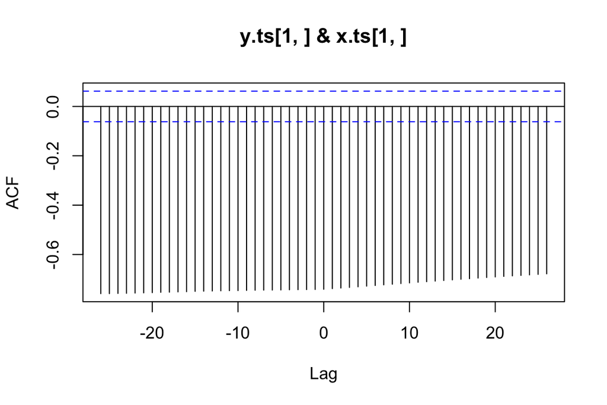

- Correlation coefficients (ccf at lag 0)
- Distance correlation
- Standard beta correlation
- Rejection rates of linear and distance correlation test

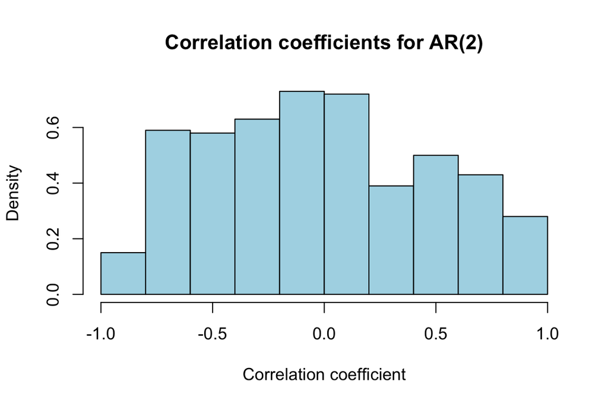

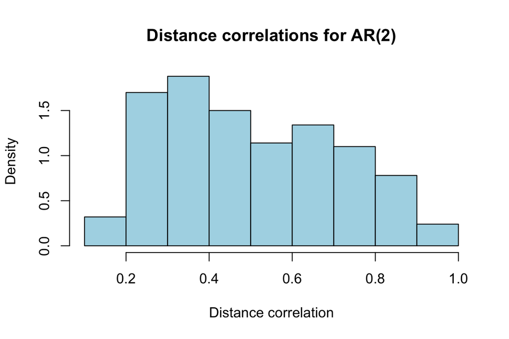

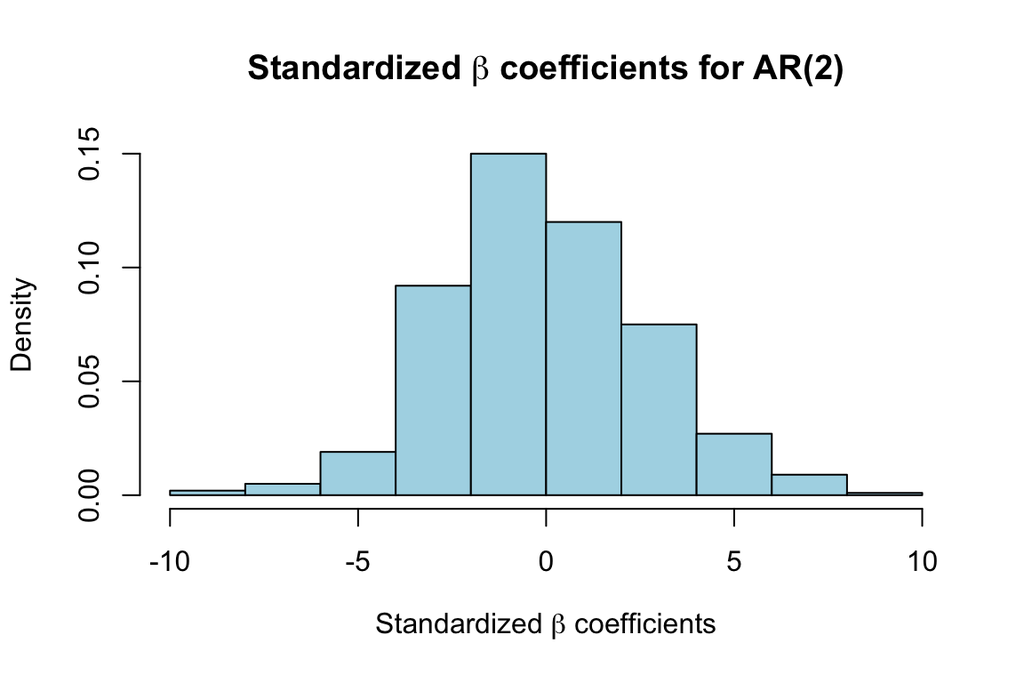

Rejection rates for linear and distance correlation test

| linear.test | dis.test |
| --- | --- |
| 0.91 | 1 |

## AR(2) (0.5,0.3)

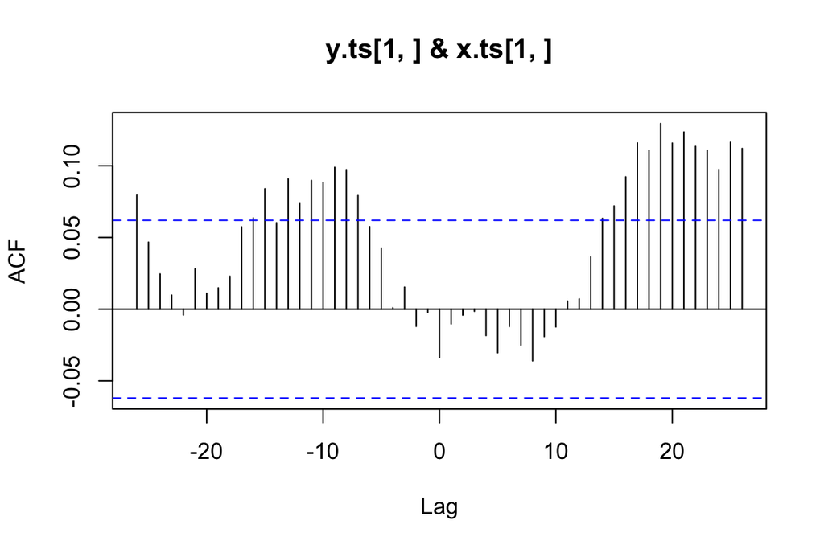

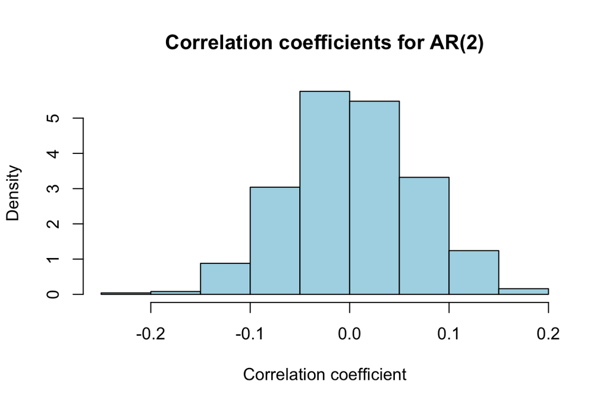

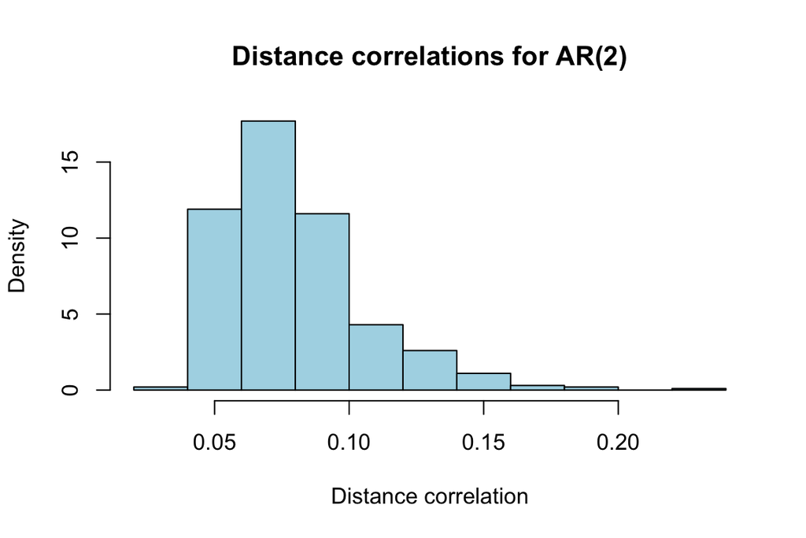

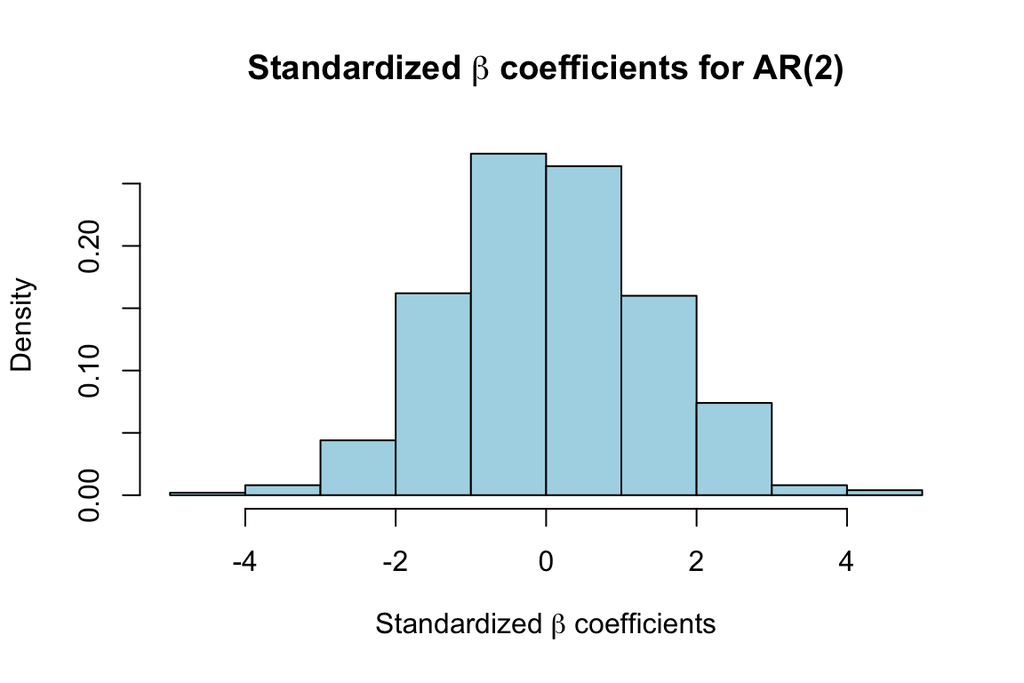

Rejection rates for linear and distance correlation test

| linear.test | dis.test |
| --- | --- |
| 0.336 | 0.516 |

## AR(2) (-0.5, -0.3)

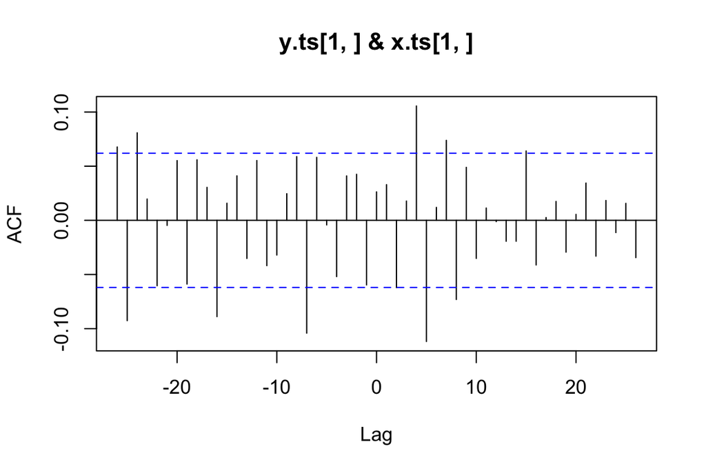

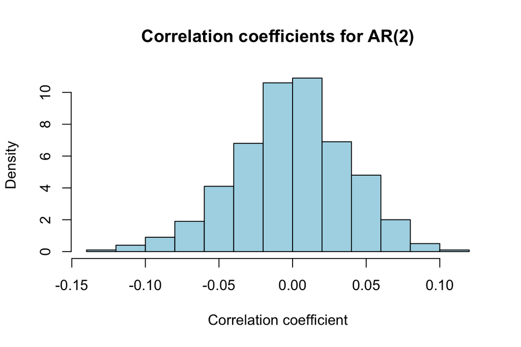

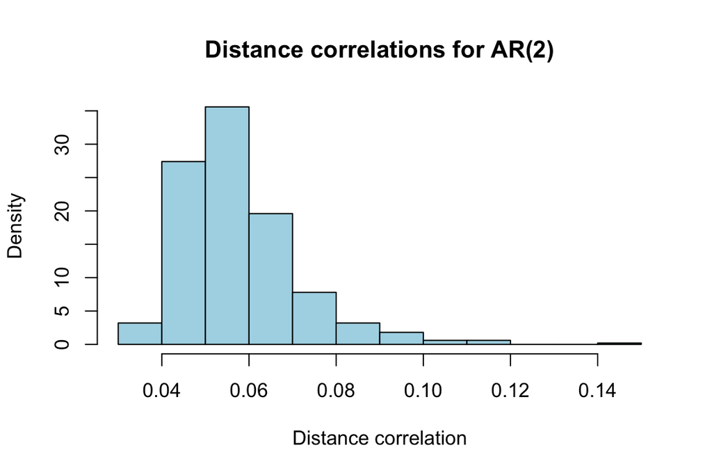

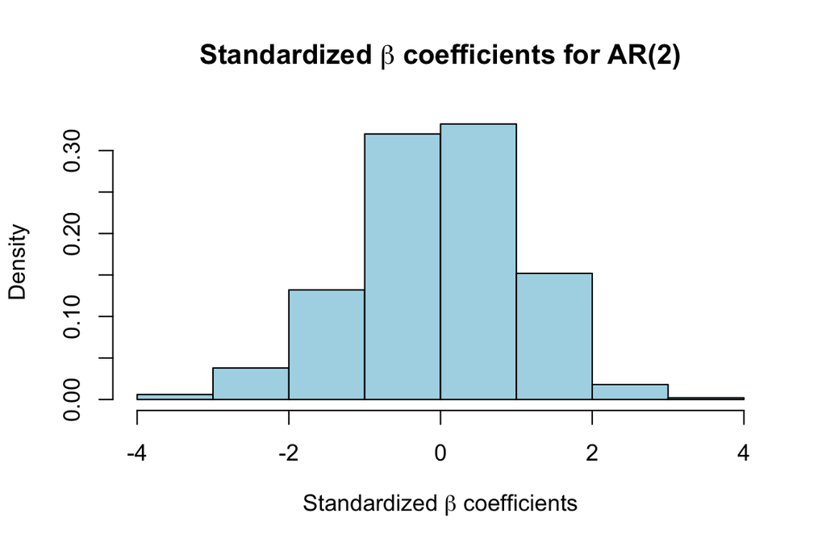

Rejection rates for linear and distance correlation test

| linear.test | dis.test |
| --- | --- |
| 0.102 | 0.096 |

## AR(2) (-0.6, -0.3)

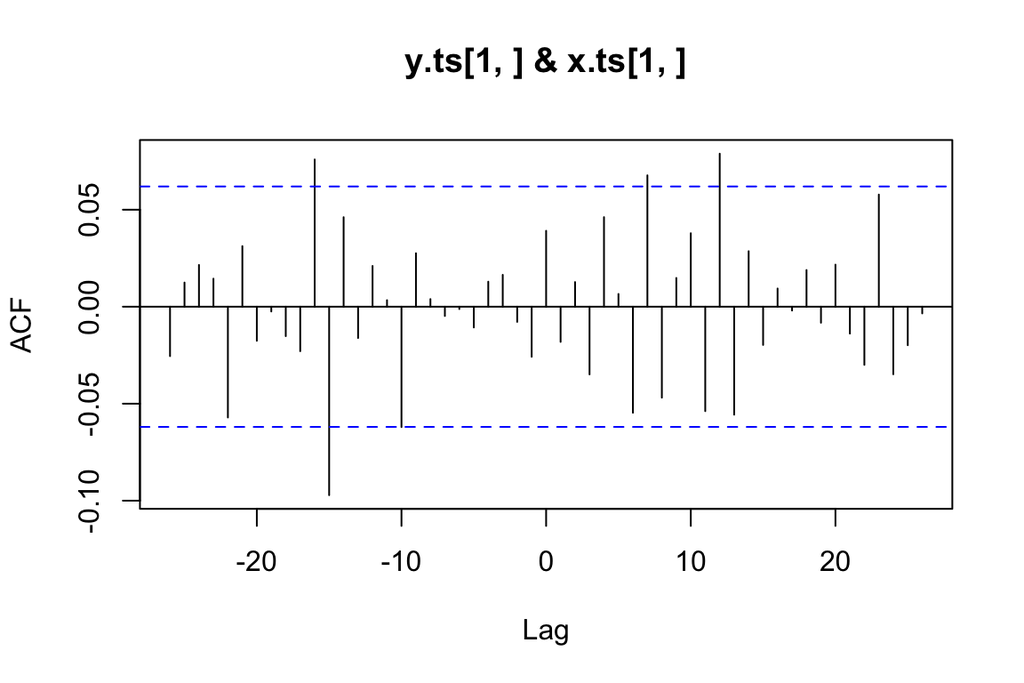

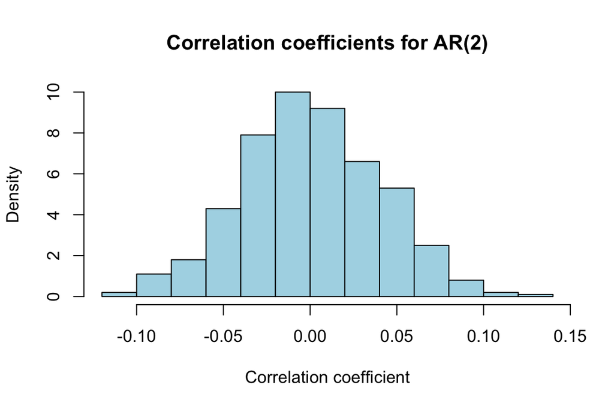

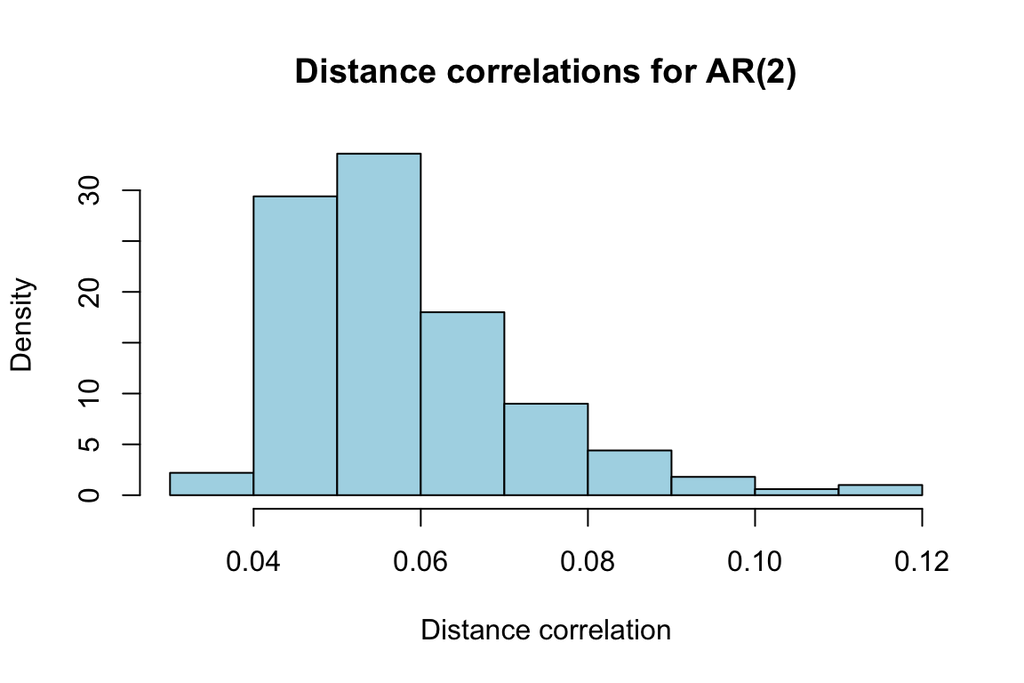

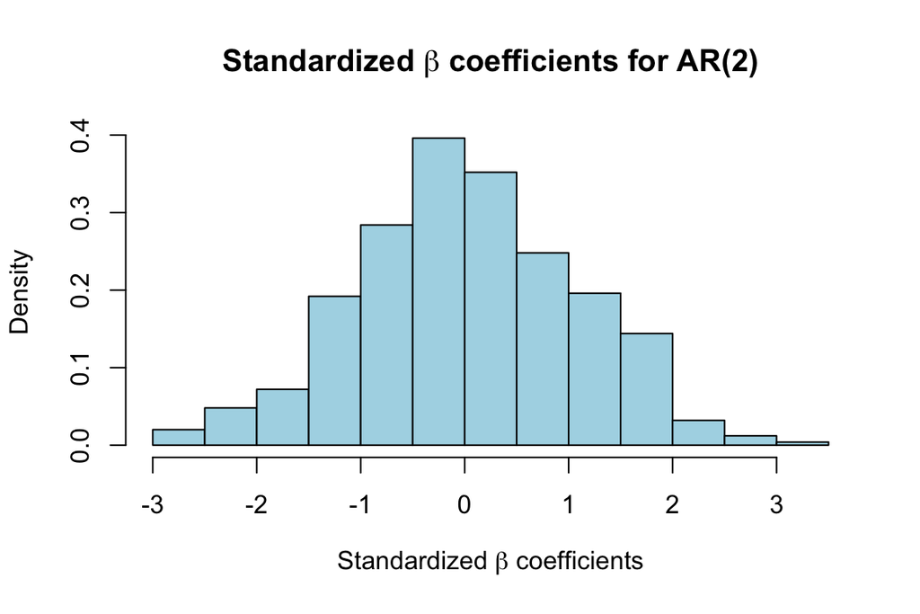

Rejection rates for linear and distance correlation test

| linear.test | dis.test |
| --- | --- |
| 0.112 | 0.13 |